# Assignment 7

##### CS 6420

### Description

#### Imagine yourself working as a cashier in a region where paper is very rare and valuable. By law, cashiers are required to use the fewest bills possible when giving change. Assume that in this region you have the following denominations (in local dollars): $\$1$, $\$4$, $\$7$, $\$13$, $\$28$, $\$52$, $\$91$, and $\$365$.

##### A. The greedy change algorithm repeatedly takes the largest bill that does not exceed the target amount. For example, the amount $\$118$ has the following change according to this greedy algorithm: a $\$91$ bill, a $\$13$ bill, another $\$13$ bill, and finally a $\$1$ bill. Prove by example (give an example) that this algorithm is not optimal: it uses more bills than the minimum possible.

Code for solving this problem is found at the end of the document.

##### B. Give a recursive algorithm implementing the greedy algorithm of STEP A.

```python
def greedy(coins, selected, remain):
    if remain <= 0:
        return

    for i in coins[::-1]:
        if i <= remain:
            selected.append(i)
            greedy(coins, selected, remain-i)
            return
    return

S=[]
C = [1, 4, 7, 13, 28, 52, 91, 365]
Goal = 416
greedy(C, S, Goal)
print(S)
```

```
[365, 28, 13, 7, 1, 1, 1]
```

##### C. Write a recurrence equation that expresses the minimum number of bills $N(k)$ for a positive integer amount $k$.

$N(k) = \begin{cases} 0 & \text{if $k=0$} \\ \min_{x_i\leq k}{[N(k-x_i)+1]} & \text{if $k>2$} \end{cases}$

##### D. Draw the full recursion tree of $N(10)$ based on the recurrence of STEP C.

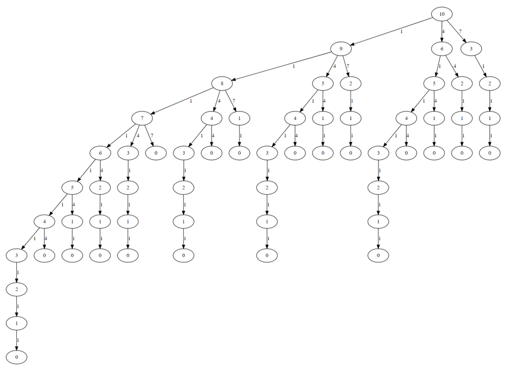

##### E. What is the optimal value for $N(10)$? What bills are in the change of amount $10$ based on the greedy algorithm of STEP A.

The optimal value is $N(10) = 4$. If we were to use the greedy algorithm $G$, then $G(10) = 4$ with the solution being $\$10 = \$7 + \$1 + \$1 + \$1 $.

##### F. Give a recursive top-down memoized dynamic programming algorithm implementing the recurrence of STEP B. Save whatever information you need to make the algorithm of STEP J possible.

```python
def wrapTopDown(money, goal):
    count = [0]*(goal+1)
    answer = recTopDown(count, money, goal)
#     print("Index\t\tSolutions: ")
#     for index, i in enumerate(solutions):
#         print(index, "\t\t",i)
    print(count)
    return answer

def recTopDown(count, money, remaining):
    if remaining <= 0:
        return count[0]
    if count[remaining] <= 0:
        m = remaining
        for i in [remaining - k for k in money if k <= remaining]:
            m = min(recTopDown(count, money, i), m)
        count[remaining] = m+1
    return count[remaining]

goal = 118
money = [1, 4, 7, 13, 28, 52, 91, 365]

answer = wrapTopDown(money, goal)
# print(money)
# print(goal)
print("\nFinal Answer: N(" + str(goal) + ") = ", answer)
```

```
[0, 1, 2, 3, 1, 2, 3, 1, 2, 3, 4, 2, 3, 1, 2, 3, 4, 2, 3, 4, 2, 3, 4, 5, 3, 4, 2, 3, 1, 2, 3, 4, 2, 3, 4, 2, 3, 4, 5, 3, 4, 2, 3, 4, 5, 3, 4, 5, 3, 4, 5, 6, 1, 2, 3, 4, 2, 3, 4, 2, 3, 4, 5, 3, 4, 2, 3, 4, 5, 3, 4, 5, 3, 4, 5, 6, 4, 5, 3, 4, 2, 3, 4, 5, 3, 4, 5, 3, 4, 5, 6, 1, 2, 3, 4, 2, 3, 4, 2, 3,…

Final Answer: N(118) =  4
```

##### G. Give an iterative bottom-up dynamic programming algorithm implementing the recurrence of STEP B. Save whatever information you need to make the algorithm of STEP J possible.

```python
def bottomUp(money, goal):
    count = [0]*(goal+1)
    solutions = [0]*(goal+1)
    for c in range(1, goal+1):
        minimum = goal
        for m in [k for k in money if k <= c]:
            temp = 1+count[c-m]
            if temp < minimum:
                minimum = temp
                val = m
        count[c] = minimum
        solutions[c] = val
    print(count)
    return count[goal]

goal = 118
money = [1, 4, 7, 13, 28, 52, 91, 365]

answer = bottomUp(money, goal)
print("\nFinal Answer: N(" + str(goal) + ") = ", answer)
```

```
[0, 1, 2, 3, 1, 2, 3, 1, 2, 3, 4, 2, 3, 1, 2, 3, 4, 2, 3, 4, 2, 3, 4, 5, 3, 4, 2, 3, 1, 2, 3, 4, 2, 3, 4, 2, 3, 4, 5, 3, 4, 2, 3, 4, 5, 3, 4, 5, 3, 4, 5, 6, 1, 2, 3, 4, 2, 3, 4, 2, 3, 4, 5, 3, 4, 2, 3, 4, 5, 3, 4, 5, 3, 4, 5, 6, 4, 5, 3, 4, 2, 3, 4, 5, 3, 4, 5, 3, 4, 5, 6, 1, 2, 3, 4, 2, 3, 4, 2, 3,…

Final Answer: N(118) =  4
```

##### H. What is the running time of STEP F algorithm?

There will be some startup cost for this function, since the auxilliary array used to memorize answers starts out unfilled. When the algorithm begins, it must recursively iterate down to the lowerst values in our memorized array "count". The recursion will have a lot of overhead, which performance will depend on the machine/available memory allotted for the program. But theoretically, after the recursive function has done all the start-up work, for each value in the "count" will (in the worst case) be used as many times as there are values in the "money" array so that a minimum value can be chosen.

With the goal of finding the minimum bills $b$ for a specified amount $k$ that can be made with $n$ different bill values, the top-down function $N$ computes $N(k) = b$. The time complexity is $\Theta(nk)$.

##### I. What is the running time of the STEP G algorithm?

Each of the $n$ different bill values that can be combined to make change for an amount $k$ must be used for each value less than $k$ in the bottom-up approach. The two FOR loops very clearly express the time complexity, which similar to the above is $\Theta(nk)$. The main difference between the top-down and the bottom-up methods is that the overhead from the top-down solution makes it very slow for high input values.

##### J. Give an algorithm for printing the actual bills of the optimal change of $N(k)$. For example, for $k=118$, this function should print something like: $\$118 = \$1 + \$13 + \$13 + \$91$.

Because the bottom-up solution is prefereable, I made the modifications to it to supply the desired output. The trick is to keep track of which bill value was associated with the minimum variable when the inner IF statement is called. This leaves a trail for us to find which combination of bills yielded our solution.

We make a new array that is initialized the same as count array. Like the count array, the index will represent an amount of money. The entry at index $i$ represents the last bill in the minimum combination solution. This is stored when we find the minimum value of the current amount minus that bill. To find the combination, we start with the desired amount $a$ whose combination we want to know, take the value at that index $solutions[a]$, us it to reference the next value $a = a - solutions[a]$. We continue to update our index $a$, keeping track of the values at each of those indexes, until $a=0$. All of those values are the solution. See code below:

```python
def explicitSolution(S):
    result = []
    a = len(S)-1
    while a > 0:
        result.append(S[a])
        a = a - S[a]
    return result


def bottomUp(money, goal):
    count = [0]*(goal+1)
    solutions = [0]*(goal+1)
    for c in range(1, goal+1):
        minimum = goal
        for m in [k for k in money if k <= c]:
            temp = 1+count[c-m]
            if temp < minimum:
                minimum = temp
                val = m
        count[c] = minimum
        solutions[c] = val
    bills = explicitSolution(solutions)
    print(count)
    return count[goal], bills

goal = 118
money = [1, 4, 7, 13, 28, 52, 91, 365]

a1, a2 = bottomUp(money, goal)
a2 = "$" + str(goal) + " = " + " + ".join(["$"+str(i) for i in a2])
print("\nFinal Answer: N(" + str(goal) + ") = ", a1, "\nwith: ", a2)
```

```
[0, 1, 2, 3, 1, 2, 3, 1, 2, 3, 4, 2, 3, 1, 2, 3, 4, 2, 3, 4, 2, 3, 4, 5, 3, 4, 2, 3, 1, 2, 3, 4, 2, 3, 4, 2, 3, 4, 5, 3, 4, 2, 3, 4, 5, 3, 4, 5, 3, 4, 5, 6, 1, 2, 3, 4, 2, 3, 4, 2, 3, 4, 5, 3, 4, 2, 3, 4, 5, 3, 4, 5, 3, 4, 5, 6, 4, 5, 3, 4, 2, 3, 4, 5, 3, 4, 5, 3, 4, 5, 6, 1, 2, 3, 4, 2, 3, 4, 2, 3,…

Final Answer: N(118) =  4
with:  $118 = $1 + $13 + $13 + $91
```

#### The code below calculates the first instance when the greedy algorithm and the optimized algorithm do not match in problem A.

```python
def greedy(coins, selected, remain):
    if remain <= 0:
        return

    for i in coins[::-1]:
        if i <= remain:
            selected.append(i)
            greedy(coins, selected, remain-i)
            return len(selected)
    return len(selected)

def bottomUp(money, goal):
    count = [0]*(goal+1)
    solutions = [0]*(goal+1)
    val = 0
    for c in range(1, goal+1):
        minimum = goal
        for m in [k for k in money if k <= c]:
            temp = 1+count[c-m]
            if temp < minimum:
                minimum = temp
                val = m
        count[c] = minimum
        solutions[c] = val
#     print(count)
    return count[goal]

goal = 118
money = [1, 4, 7, 13, 28, 52, 91, 365]

answer = bottomUp(money, goal)
# print("\nFinal Answer: N(" + str(goal) + ") = ", answer)

goal = 2
while True:
    S = []
    a = greedy(money, S, goal)
    b = bottomUp(money, goal)
    if b < a:
        print(goal)
        break
    goal += 1
```

```
416
```